# Baseline envRS and PRS for longitudinal outcomes

Baseline envRS were trained on parent-reported CBCL subscales for internalizing (intRS) and depression (depRS) symptoms. Here I am testing associations between baseline envRS and longitudinal outcomes, plus the combination of envRS and MDD3 PRS.

PRS data based on MDD3 GWAS (from Poppy) were available for 4161 participants. At year 3, CBCL data were available for 8306 participants. A total of 2818 participants have year 3 CBCL data, PRS and baseline envRS.  
Model comparisons are run for:  
m1 = cbcl ~ envRS  
m2 = cbcl ~ envRS + PRS  
m3 = cbcl ~ envRS*PRS

# Y3 CBCL Depression

## depRS + PRS

### Performance metrics

| Name | Model | AIC (weights) | AICc (weights) | BIC (weights) | R2 | R2 (adj.) | RMSE | Sigma |
| --- | --- | --- | --- | --- | --- | --- | --- | --- |
| m1 | lm | 7902.5 (<.001) | 7902.5 (<.001) | 7920.3 (0.023) | 0.106 | 0.106 | 0.983 | 0.984 |
| m2 | lm | 7892.5 (0.011) | 7892.5 (0.011) | 7916.3 (0.169) | 0.110 | 0.110 | 0.981 | 0.982 |
| m3 | lm | 7883.4 (0.989) | 7883.5 (0.989) | 7913.2 (0.809) | 0.114 | 0.113 | 0.979 | 0.980 |

### Model comparisons

| Name | Model | BF | df | df_diff | Chi2 | p |
| --- | --- | --- | --- | --- | --- | --- |
| m1 | lm |  | 3 |  |  |  |
| m2 | lm | 7.38 | 4 | 1.000 | 11.941 | < .001 |
| m3 | lm | 4.79 | 5 | 1.000 | 11.078 | < .001 |

Models were detected as nested (in terms of fixed parameters) and are compared in sequential order.

### Plot

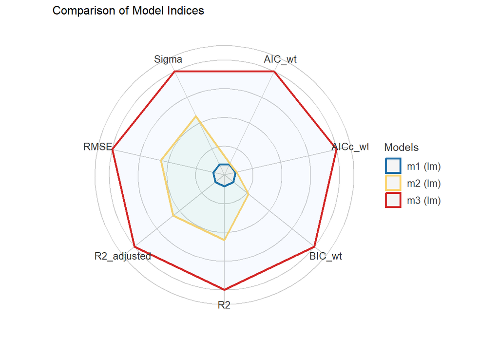

### Estimates

|  | m1 |  |  |  | m2 |  |  |  | m3 |  |  |  |
| --- | --- | --- | --- | --- | --- | --- | --- | --- | --- | --- | --- | --- |
| Predictors | Estimates | std. Error | Statistic | p | Estimates | std. Error | Statistic | p | Estimates | std. Error | Statistic | p |
| (Intercept) | 0.08 (0.04 – 0.12) | 0.02 | 4.34 | **<0.001** | 0.08 (0.04 – 0.12) | 0.02 | 4.34 | **<0.001** | 0.07 (0.04 – 0.11) | 0.02 | 3.92 | **<0.001** |
| depRS b | 0.35 (0.31 – 0.38) | 0.02 | 18.31 | **<0.001** | 0.34 (0.30 – 0.38) | 0.02 | 17.83 | **<0.001** | 0.33 (0.29 – 0.37) | 0.02 | 17.31 | **<0.001** |
| PRS |  |  |  |  | 0.06 (0.03 – 0.10) | 0.02 | 3.46 | **0.001** | 0.07 (0.03 – 0.10) | 0.02 | 3.54 | **<0.001** |
| depRS b × PRS |  |  |  |  |  |  |  |  | 0.06 (0.03 – 0.10) | 0.02 | 3.33 | **0.001** |
| Observations | 2816 |  |  |  | 2816 |  |  |  | 2816 |  |  |  |
| R<sup>2</sup> / R<sup>2</sup> adjusted | 0.106 / 0.106 |  |  |  | 0.110 / 0.110 |  |  |  | 0.114 / 0.113 |  |  |  |

| model | Accuracy | SE | CI | CI_low | CI_high | Method |
| --- | --- | --- | --- | --- | --- | --- |
| m1 | 0.324 | 0.091 | 0.95 | 0.246 | 0.460 | Correlation between observed and predicted |
| m2 | 0.332 | 0.020 | 0.95 | 0.301 | 0.347 | Correlation between observed and predicted |
| m3 | 0.332 | 0.064 | 0.95 | 0.267 | 0.420 | Correlation between observed and predicted |

## envRS combined

Uses larger sample of envRS only data (N = 6561)

### Performance metrics

| Name | Model | AIC (weights) | AICc (weights) | BIC (weights) | R2 | R2 (adj.) | RMSE | Sigma |
| --- | --- | --- | --- | --- | --- | --- | --- | --- |
| dep_mod | lm | 17875.2 (<.001) | 17875.2 (<.001) | 17895.5 (<.001) | 0.098 | 0.098 | 0.945 | 0.945 |
| comb_mod | lm | 17808.4 (0.704) | 17808.4 (0.704) | 17835.5 (0.986) | 0.107 | 0.107 | 0.940 | 0.940 |
| interact | lm | 17810.1 (0.296) | 17810.1 (0.296) | 17844.1 (0.014) | 0.108 | 0.107 | 0.940 | 0.940 |

### Model comparisons

| Name | Model | BF | df | df_diff | Chi2 | p |
| --- | --- | --- | --- | --- | --- | --- |
| dep_mod | lm |  | 3 |  |  |  |
| comb_mod | lm | > 1000 | 4 | 1.000 | 68.776 | < .001 |
| interact | lm | 0.014 | 5 | 1.000 | 0.269 | 0.604 |

Models were detected as nested (in terms of fixed parameters) and are compared in sequential order.

### Plot

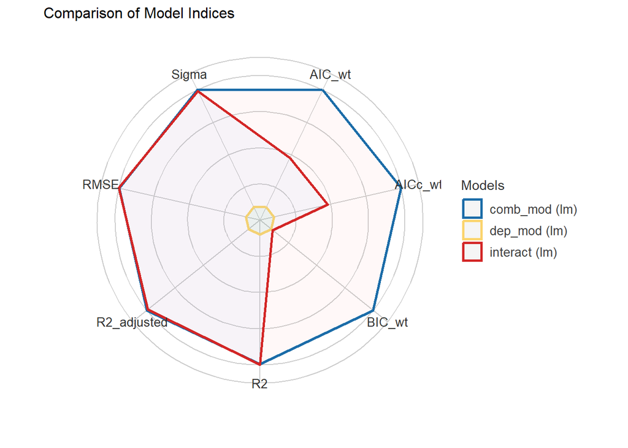

### Estimates

|  | dep_mod |  |  |  | comb_mod |  |  |  | interact |  |  |  |
| --- | --- | --- | --- | --- | --- | --- | --- | --- | --- | --- | --- | --- |
| Predictors | Estimates | std. Error | Statistic | p | Estimates | std. Error | Statistic | p | Estimates | std. Error | Statistic | p |
| (Intercept) | 0.02 (-0.01 – 0.04) | 0.01 | 1.44 | 0.150 | 0.01 (-0.01 – 0.04) | 0.01 | 1.29 | 0.199 | 0.02 (-0.01 – 0.05) | 0.01 | 1.36 | 0.173 |
| depRS b | 0.68 (0.63 – 0.73) | 0.03 | 26.70 | **<0.001** | -0.09 (-0.28 – 0.10) | 0.10 | -0.94 | 0.349 | -0.09 (-0.27 – 0.10) | 0.10 | -0.90 | 0.366 |
| intRS b |  |  |  |  | 0.75 (0.58 – 0.93) | 0.09 | 8.31 | **<0.001** | 0.76 (0.58 – 0.94) | 0.09 | 8.30 | **<0.001** |
| depRS b × intRS b |  |  |  |  |  |  |  |  | -0.02 (-0.08 – 0.05) | 0.03 | -0.52 | 0.604 |
| Observations | 6559 |  |  |  | 6559 |  |  |  | 6559 |  |  |  |
| R<sup>2</sup> / R<sup>2</sup> adjusted | 0.098 / 0.098 |  |  |  | 0.107 / 0.107 |  |  |  | 0.108 / 0.107 |  |  |  |

| model | Accuracy | SE | CI | CI_low | CI_high | Method |
| --- | --- | --- | --- | --- | --- | --- |
| dep_mod | 0.314 | 0.011 | 0.95 | 0.299 | 0.325 | Correlation between observed and predicted |
| comb_mod | 0.329 | 0.047 | 0.95 | 0.259 | 0.376 | Correlation between observed and predicted |
| interact | 0.326 | 0.032 | 0.95 | 0.285 | 0.360 | Correlation between observed and predicted |

# Y3 CBCL Internalising

## intRS + PRS

### Performance metrics

| Name | Model | AIC (weights) | AICc (weights) | BIC (weights) | R2 | R2 (adj.) | RMSE | Sigma |
| --- | --- | --- | --- | --- | --- | --- | --- | --- |
| m1 | lm | 7730.7 (<.001) | 7730.7 (<.001) | 7748.5 (<.001) | 0.124 | 0.124 | 0.954 | 0.954 |
| m2 | lm | 7715.3 (<.001) | 7715.3 (<.001) | 7739.0 (0.007) | 0.129 | 0.129 | 0.951 | 0.951 |
| m3 | lm | 7699.3 (>.999) | 7699.3 (>.999) | 7729.0 (0.993) | 0.135 | 0.134 | 0.948 | 0.948 |

### Model comparisons

| Name | Model | BF | df | df_diff | Chi2 | p |
| --- | --- | --- | --- | --- | --- | --- |
| m1 | lm |  | 3 |  |  |  |
| m2 | lm | 113.46 | 4 | 1.000 | 17.406 | < .001 |
| m3 | lm | 152.36 | 5 | 1.000 | 17.996 | < .001 |

Models were detected as nested (in terms of fixed parameters) and are compared in sequential order.

### Plot

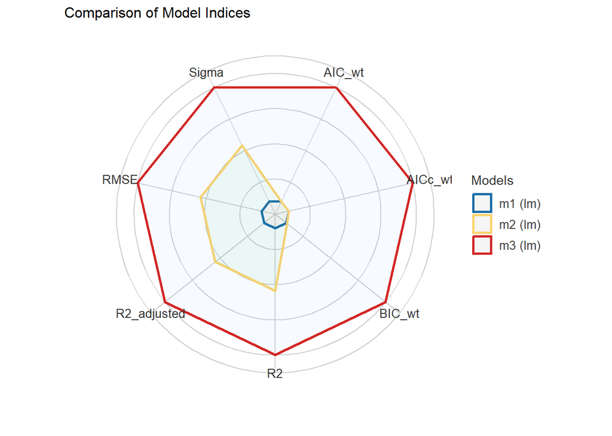

### Estimates

|  | m1 |  |  |  | m2 |  |  |  | m3 |  |  |  |
| --- | --- | --- | --- | --- | --- | --- | --- | --- | --- | --- | --- | --- |
| Predictors | Estimates | std. Error | Statistic | p | Estimates | std. Error | Statistic | p | Estimates | std. Error | Statistic | p |
| (Intercept) | 0.08 (0.04 – 0.11) | 0.02 | 4.38 | **<0.001** | 0.08 (0.04 – 0.11) | 0.02 | 4.38 | **<0.001** | 0.07 (0.03 – 0.11) | 0.02 | 3.89 | **<0.001** |
| intRS b | 0.37 (0.33 – 0.40) | 0.02 | 19.97 | **<0.001** | 0.36 (0.32 – 0.39) | 0.02 | 19.45 | **<0.001** | 0.35 (0.31 – 0.39) | 0.02 | 18.84 | **<0.001** |
| PRS |  |  |  |  | 0.08 (0.04 – 0.11) | 0.02 | 4.18 | **<0.001** | 0.08 (0.04 – 0.11) | 0.02 | 4.26 | **<0.001** |
| intRS b × PRS |  |  |  |  |  |  |  |  | 0.08 (0.04 – 0.11) | 0.02 | 4.25 | **<0.001** |
| Observations | 2816 |  |  |  | 2816 |  |  |  | 2816 |  |  |  |
| R<sup>2</sup> / R<sup>2</sup> adjusted | 0.124 / 0.124 |  |  |  | 0.129 / 0.129 |  |  |  | 0.135 / 0.134 |  |  |  |

| model | Accuracy | SE | CI | CI_low | CI_high | Method |
| --- | --- | --- | --- | --- | --- | --- |
| m1 | 0.352 | 0.023 | 0.95 | 0.319 | 0.377 | Correlation between observed and predicted |
| m2 | 0.360 | 0.043 | 0.95 | 0.314 | 0.417 | Correlation between observed and predicted |
| m3 | 0.364 | 0.075 | 0.95 | 0.265 | 0.455 | Correlation between observed and predicted |

## envRS combined

Uses larger sample of envRS only data (N = 6561)

### Performance metrics

| Name | Model | AIC (weights) | AICc (weights) | BIC (weights) | R2 | R2 (adj.) | RMSE | Sigma |
| --- | --- | --- | --- | --- | --- | --- | --- | --- |
| int_mod | lm | 17717.3 (<.001) | 17717.3 (<.001) | 17737.7 (<.001) | 0.126 | 0.125 | 0.934 | 0.934 |
| comb_mod | lm | 17681.2 (0.693) | 17681.2 (0.693) | 17708.4 (0.985) | 0.131 | 0.130 | 0.931 | 0.931 |
| interact | lm | 17682.9 (0.307) | 17682.9 (0.307) | 17716.8 (0.015) | 0.131 | 0.130 | 0.931 | 0.931 |

### Model comparisons

| Name | Model | BF | df | df_diff | Chi2 | p |
| --- | --- | --- | --- | --- | --- | --- |
| int_mod | lm |  | 3 |  |  |  |
| comb_mod | lm | > 1000 | 4 | 1.000 | 38.092 | < .001 |
| interact | lm | 0.015 | 5 | 1.000 | 0.371 | 0.542 |

Models were detected as nested (in terms of fixed parameters) and are compared in sequential order.

### Plot

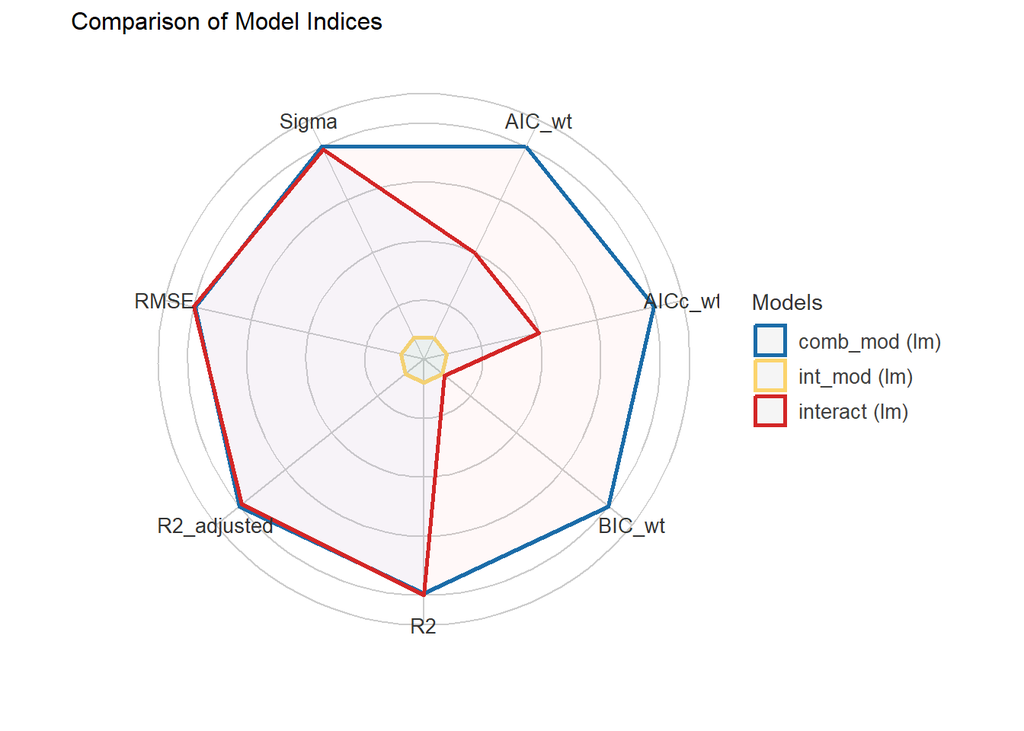

### Estimates

|  | int_mod |  |  |  | comb_mod |  |  |  | interact |  |  |  |
| --- | --- | --- | --- | --- | --- | --- | --- | --- | --- | --- | --- | --- |
| Predictors | Estimates | std. Error | Statistic | p | Estimates | std. Error | Statistic | p | Estimates | std. Error | Statistic | p |
| (Intercept) | 0.02 (-0.01 – 0.04) | 0.01 | 1.48 | 0.140 | 0.02 (-0.01 – 0.04) | 0.01 | 1.31 | 0.189 | 0.02 (-0.01 – 0.05) | 0.01 | 1.44 | 0.151 |
| intRS b | 0.73 (0.68 – 0.78) | 0.02 | 30.68 | **<0.001** | 1.27 (1.09 – 1.44) | 0.09 | 14.08 | **<0.001** | 1.27 (1.10 – 1.45) | 0.09 | 14.01 | **<0.001** |
| depRS b |  |  |  |  | -0.58 (-0.77 – -0.40) | 0.09 | -6.18 | **<0.001** | -0.58 (-0.77 – -0.40) | 0.09 | -6.13 | **<0.001** |
| intRS b × depRS b |  |  |  |  |  |  |  |  | -0.02 (-0.09 – 0.04) | 0.03 | -0.61 | 0.542 |
| Observations | 6559 |  |  |  | 6559 |  |  |  | 6559 |  |  |  |
| R<sup>2</sup> / R<sup>2</sup> adjusted | 0.126 / 0.125 |  |  |  | 0.131 / 0.130 |  |  |  | 0.131 / 0.130 |  |  |  |

| model | Accuracy | SE | CI | CI_low | CI_high | Method |
| --- | --- | --- | --- | --- | --- | --- |
| int_mod | 0.355 | 0.017 | 0.95 | 0.342 | 0.378 | Correlation between observed and predicted |
| comb_mod | 0.360 | 0.023 | 0.95 | 0.341 | 0.395 | Correlation between observed and predicted |
| interact | 0.360 | 0.029 | 0.95 | 0.329 | 0.397 | Correlation between observed and predicted |

# Y4 CBCL Depression

At year 4, CBCL data were available for 3807 participants. A total 1357 participants have year 4 CBCL data, PRS and baseline envRS.  
Model comparisons are run for:  
m1 = cbcl ~ envRS  
m2 = cbcl ~ envRS + PRS  
m3 = cbcl ~ envRS*PRS

## depRS + PRS

### Performance metrics

| Name | Model | AIC (weights) | AICc (weights) | BIC (weights) | R2 | R2 (adj.) | RMSE | Sigma |
| --- | --- | --- | --- | --- | --- | --- | --- | --- |
| m1 | lm | 3688.2 (0.011) | 3688.3 (0.012) | 3703.9 (0.174) | 0.063 | 0.063 | 0.940 | 0.940 |
| m2 | lm | 3680.0 (0.719) | 3680.0 (0.720) | 3700.8 (0.804) | 0.071 | 0.069 | 0.936 | 0.937 |
| m3 | lm | 3681.9 (0.269) | 3682.0 (0.268) | 3708.0 (0.022) | 0.071 | 0.069 | 0.936 | 0.938 |

### Model comparisons

| Name | Model | BF | df | df_diff | Chi2 | p |
| --- | --- | --- | --- | --- | --- | --- |
| m1 | lm |  | 3 |  |  |  |
| m2 | lm | 4.63 | 4 | 1.000 | 10.278 | 0.001 |
| m3 | lm | 0.028 | 5 | 1.000 | 0.037 | 0.848 |

Models were detected as nested (in terms of fixed parameters) and are compared in sequential order.

### Plot

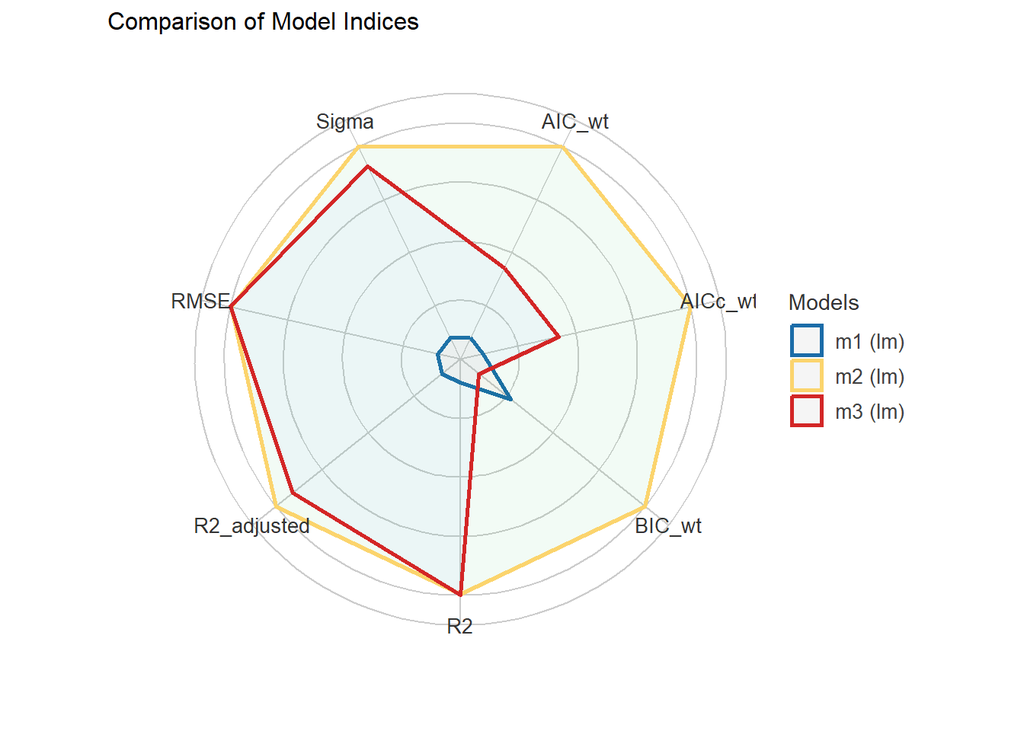

### Estimates

|  | m1 |  |  |  | m2 |  |  |  | m3 |  |  |  |
| --- | --- | --- | --- | --- | --- | --- | --- | --- | --- | --- | --- | --- |
| Predictors | Estimates | std. Error | Statistic | p | Estimates | std. Error | Statistic | p | Estimates | std. Error | Statistic | p |
| (Intercept) | 0.03 (-0.02 – 0.08) | 0.03 | 1.09 | 0.275 | 0.03 (-0.02 – 0.08) | 0.03 | 1.08 | 0.280 | 0.03 (-0.02 – 0.08) | 0.03 | 1.04 | 0.298 |
| depRS b | 0.26 (0.21 – 0.31) | 0.03 | 9.58 | **<0.001** | 0.25 (0.19 – 0.30) | 0.03 | 9.09 | **<0.001** | 0.25 (0.19 – 0.30) | 0.03 | 9.00 | **<0.001** |
| PRS |  |  |  |  | 0.08 (0.03 – 0.13) | 0.03 | 3.21 | **0.001** | 0.08 (0.03 – 0.13) | 0.03 | 3.21 | **0.001** |
| depRS b × PRS |  |  |  |  |  |  |  |  | 0.01 (-0.05 – 0.06) | 0.03 | 0.19 | 0.848 |
| Observations | 1357 |  |  |  | 1357 |  |  |  | 1357 |  |  |  |
| R<sup>2</sup> / R<sup>2</sup> adjusted | 0.063 / 0.063 |  |  |  | 0.071 / 0.069 |  |  |  | 0.071 / 0.069 |  |  |  |

| model | Accuracy | SE | CI | CI_low | CI_high | Method |
| --- | --- | --- | --- | --- | --- | --- |
| m1 | 0.252 | 0.041 | 0.95 | 0.200 | 0.287 | Correlation between observed and predicted |
| m2 | 0.265 | 0.063 | 0.95 | 0.191 | 0.338 | Correlation between observed and predicted |
| m3 | 0.267 | 0.074 | 0.95 | 0.196 | 0.367 | Correlation between observed and predicted |

## envRS combined

Uses larger sample of envRS only data (N = 3078)

### Performance metrics

| Name | Model | AIC (weights) | AICc (weights) | BIC (weights) | R2 | R2 (adj.) | RMSE | Sigma |
| --- | --- | --- | --- | --- | --- | --- | --- | --- |
| dep_mod | lm | 8465.1 (<.001) | 8465.2 (<.001) | 8483.2 (<.001) | 0.070 | 0.069 | 0.957 | 0.957 |
| comb_mod | lm | 8410.6 (0.077) | 8410.6 (0.078) | 8434.7 (0.631) | 0.087 | 0.086 | 0.948 | 0.948 |
| interact | lm | 8405.7 (0.923) | 8405.7 (0.922) | 8435.8 (0.369) | 0.089 | 0.088 | 0.947 | 0.947 |

### Model comparisons

| Name | Model | BF | df | df_diff | Chi2 | p |
| --- | --- | --- | --- | --- | --- | --- |
| dep_mod | lm |  | 3 |  |  |  |
| comb_mod | lm | > 1000 | 4 | 1.000 | 56.531 | < .001 |
| interact | lm | 0.584 | 5 | 1.000 | 6.956 | 0.008 |

Models were detected as nested (in terms of fixed parameters) and are compared in sequential order.

### Plot

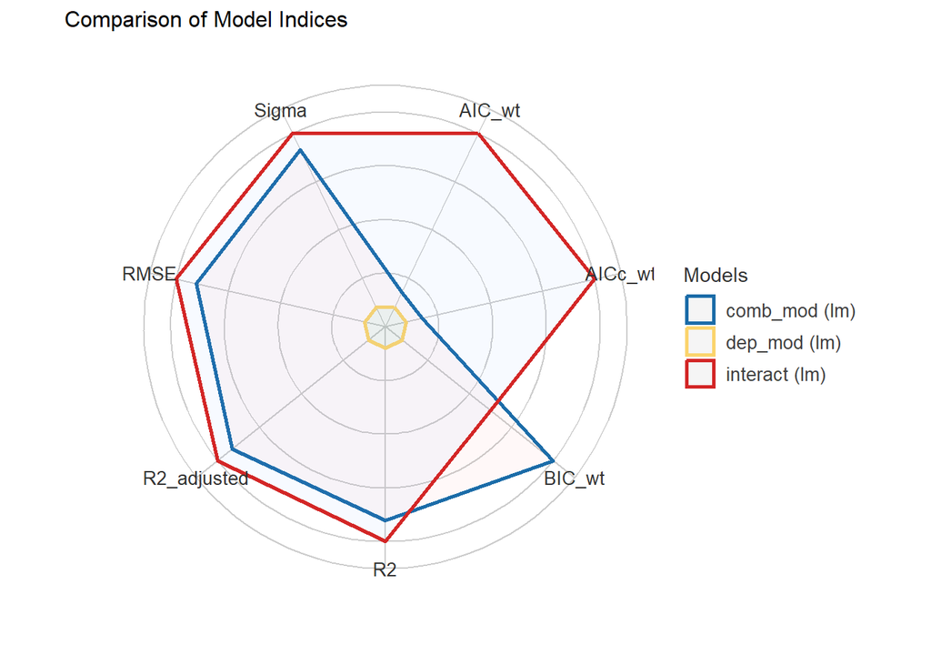

### Estimates

|  | dep_mod |  |  |  | comb_mod |  |  |  | interact |  |  |  |
| --- | --- | --- | --- | --- | --- | --- | --- | --- | --- | --- | --- | --- |
| Predictors | Estimates | std. Error | Statistic | p | Estimates | std. Error | Statistic | p | Estimates | std. Error | Statistic | p |
| (Intercept) | 0.02 (-0.01 – 0.05) | 0.02 | 1.15 | 0.252 | 0.02 (-0.02 – 0.05) | 0.02 | 0.92 | 0.357 | 0.05 (0.01 – 0.09) | 0.02 | 2.22 | **0.026** |
| depRS b | 0.60 (0.52 – 0.67) | 0.04 | 15.18 | **<0.001** | -0.43 (-0.71 – -0.15) | 0.14 | -3.05 | **0.002** | -0.41 (-0.69 – -0.13) | 0.14 | -2.88 | **0.004** |
| intRS b |  |  |  |  | 1.01 (0.75 – 1.27) | 0.13 | 7.55 | **<0.001** | 1.06 (0.80 – 1.32) | 0.13 | 7.85 | **<0.001** |
| depRS b × intRS b |  |  |  |  |  |  |  |  | -0.14 (-0.24 – -0.04) | 0.05 | -2.64 | **0.008** |
| Observations | 3077 |  |  |  | 3077 |  |  |  | 3077 |  |  |  |
| R<sup>2</sup> / R<sup>2</sup> adjusted | 0.070 / 0.069 |  |  |  | 0.087 / 0.086 |  |  |  | 0.089 / 0.088 |  |  |  |

| model | Accuracy | SE | CI | CI_low | CI_high | Method |
| --- | --- | --- | --- | --- | --- | --- |
| dep_mod | 0.267 | 0.064 | 0.95 | 0.186 | 0.342 | Correlation between observed and predicted |
| comb_mod | 0.293 | 0.054 | 0.95 | 0.226 | 0.343 | Correlation between observed and predicted |
| interact | 0.293 | 0.044 | 0.95 | 0.244 | 0.349 | Correlation between observed and predicted |

# Y4 CBCL Internalising

## intRS + PRS

### Performance metrics

| Name | Model | AIC (weights) | AICc (weights) | BIC (weights) | R2 | R2 (adj.) | RMSE | Sigma |
| --- | --- | --- | --- | --- | --- | --- | --- | --- |
| m1 | lm | 3605.0 (0.011) | 3605.0 (0.012) | 3620.7 (0.173) | 0.083 | 0.082 | 0.911 | 0.912 |
| m2 | lm | 3596.7 (0.722) | 3596.8 (0.723) | 3617.6 (0.805) | 0.090 | 0.088 | 0.908 | 0.909 |
| m3 | lm | 3598.7 (0.267) | 3598.8 (0.265) | 3624.8 (0.022) | 0.090 | 0.088 | 0.908 | 0.909 |

### Model comparisons

| Name | Model | BF | df | df_diff | Chi2 | p |
| --- | --- | --- | --- | --- | --- | --- |
| m1 | lm |  | 3 |  |  |  |
| m2 | lm | 4.65 | 4 | 1.000 | 10.287 | 0.001 |
| m3 | lm | 0.027 | 5 | 1.000 | 0.008 | 0.929 |

Models were detected as nested (in terms of fixed parameters) and are compared in sequential order.

### Plot

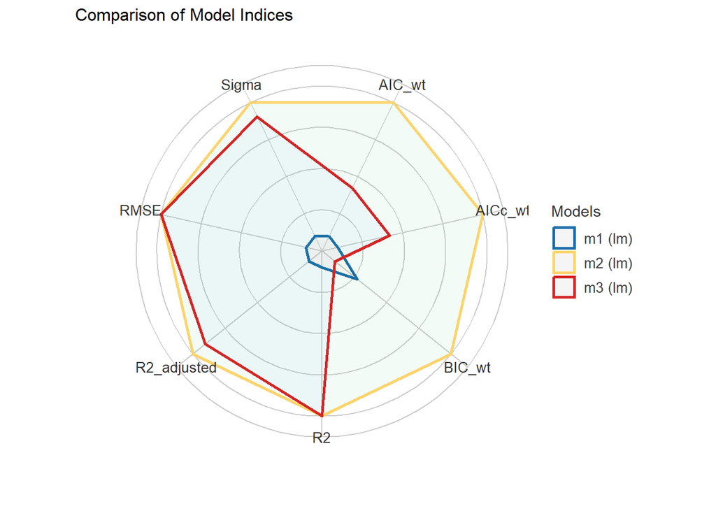

### Estimates

|  | m1 |  |  |  | m2 |  |  |  | m3 |  |  |  |
| --- | --- | --- | --- | --- | --- | --- | --- | --- | --- | --- | --- | --- |
| Predictors | Estimates | std. Error | Statistic | p | Estimates | std. Error | Statistic | p | Estimates | std. Error | Statistic | p |
| (Intercept) | 0.03 (-0.02 – 0.07) | 0.02 | 1.01 | 0.311 | 0.02 (-0.02 – 0.07) | 0.02 | 1.00 | 0.316 | 0.02 (-0.02 – 0.07) | 0.02 | 0.98 | 0.326 |
| intRS b | 0.29 (0.24 – 0.34) | 0.03 | 11.05 | **<0.001** | 0.28 (0.23 – 0.33) | 0.03 | 10.57 | **<0.001** | 0.28 (0.22 – 0.33) | 0.03 | 10.49 | **<0.001** |
| PRS |  |  |  |  | 0.08 (0.03 – 0.13) | 0.02 | 3.21 | **0.001** | 0.08 (0.03 – 0.13) | 0.02 | 3.21 | **0.001** |
| intRS b × PRS |  |  |  |  |  |  |  |  | 0.00 (-0.05 – 0.05) | 0.03 | 0.09 | 0.929 |
| Observations | 1357 |  |  |  | 1357 |  |  |  | 1357 |  |  |  |
| R<sup>2</sup> / R<sup>2</sup> adjusted | 0.083 / 0.082 |  |  |  | 0.090 / 0.088 |  |  |  | 0.090 / 0.088 |  |  |  |

| model | Accuracy | SE | CI | CI_low | CI_high | Method |
| --- | --- | --- | --- | --- | --- | --- |
| m1 | 0.290 | 0.072 | 0.95 | 0.212 | 0.378 | Correlation between observed and predicted |
| m2 | 0.302 | 0.041 | 0.95 | 0.262 | 0.348 | Correlation between observed and predicted |
| m3 | 0.290 | 0.041 | 0.95 | 0.230 | 0.324 | Correlation between observed and predicted |

## envRS combined

### Performance metrics

| Name | Model | AIC (weights) | AICc (weights) | BIC (weights) | R2 | R2 (adj.) | RMSE | Sigma |
| --- | --- | --- | --- | --- | --- | --- | --- | --- |
| int_mod | lm | 8380.6 (<.001) | 8380.6 (<.001) | 8398.6 (<.001) | 0.093 | 0.092 | 0.944 | 0.944 |
| comb_mod | lm | 8348.5 (0.016) | 8348.5 (0.016) | 8372.6 (0.253) | 0.103 | 0.102 | 0.938 | 0.939 |
| interact | lm | 8340.3 (0.984) | 8340.3 (0.984) | 8370.5 (0.747) | 0.106 | 0.105 | 0.937 | 0.937 |

### Model comparisons

| Name | Model | BF | df | df_diff | Chi2 | p |
| --- | --- | --- | --- | --- | --- | --- |
| int_mod | lm |  | 3 |  |  |  |
| comb_mod | lm | > 1000 | 4 | 1.000 | 34.036 | < .001 |
| interact | lm | 2.95 | 5 | 1.000 | 10.194 | 0.001 |

Models were detected as nested (in terms of fixed parameters) and are compared in sequential order.

### Plot

[figure not shown]

### Estimates

|  | intRS |  |  |  | intRS+depRS |  |  |  | interact |  |  |  |
| --- | --- | --- | --- | --- | --- | --- | --- | --- | --- | --- | --- | --- |
| Predictors | Estimates | std. Error | Statistic | p | Estimates | std. Error | Statistic | p | Estimates | std. Error | Statistic | p |
| (Intercept) | 0.02 (-0.02 – 0.05) | 0.02 | 0.92 | 0.356 | 0.01 (-0.02 – 0.04) | 0.02 | 0.64 | 0.524 | 0.05 (0.01 – 0.09) | 0.02 | 2.29 | **0.022** |
| intRS b | 0.65 (0.58 – 0.72) | 0.04 | 17.72 | **<0.001** | 1.39 (1.13 – 1.65) | 0.13 | 10.52 | **<0.001** | 1.45 (1.19 – 1.72) | 0.13 | 10.88 | **<0.001** |
| depRS b |  |  |  |  | -0.82 (-1.10 – -0.55) | 0.14 | -5.85 | **<0.001** | -0.79 (-1.07 – -0.52) | 0.14 | -5.65 | **<0.001** |
| intRS b × depRS b |  |  |  |  |  |  |  |  | -0.17 (-0.27 – -0.06) | 0.05 | -3.19 | **0.001** |
| Observations | 3077 |  |  |  | 3077 |  |  |  | 3077 |  |  |  |
| R<sup>2</sup> / R<sup>2</sup> adjusted | 0.093 / 0.092 |  |  |  | 0.103 / 0.102 |  |  |  | 0.106 / 0.105 |  |  |  |

$int_mod # Accuracy of Model Predictions

Accuracy (95% CI): 30.30% [24.82%, 36.48%] Method: Correlation between observed and predicted

$comb_mod # Accuracy of Model Predictions

Accuracy (95% CI): 32.07% [29.20%, 34.62%] Method: Correlation between observed and predicted

$interact # Accuracy of Model Predictions

Accuracy (95% CI): 32.31% [29.20%, 34.53%] Method: Correlation between observed and predicted

# Lifetime MDD diagnosis (youth)

Depression diagnoses (lifetime and current) from *youth-reported* KSADS are available at baseline (N=7566) and year 2 (N=7033).

# Baseline (cross-sectional)

For envRS-only analyses, there are 196 lifetime MDD cases, 42 current MDD cases and 377 cases with lifetime diagnoses of a depressive disorder (Major Depressive Disorder, Persistent Depressive Disorder (dysthymia), Depressive Disorder Unspecified).  
Of those with both envRS and PRS at baseline (N = 3145), there are 71 lifetime MDD cases, 15 current MDD cases and 131 cases with lifetime diagnoses of a depressive disorder (Major Depressive Disorder, Persistent Depressive Disorder (dysthymia), Depressive Disorder Unspecified).  
Current analyses use *just* the lifetime MDD outcome.

## depRS + PRS

### Performance metrics

| Name | Model | AIC (weights) | BIC (weights) | Tjur’s R2 | RMSE | Sigma | Log_loss | Score_log | Score_spherical | AICc (weights) | PCP |
| --- | --- | --- | --- | --- | --- | --- | --- | --- | --- | --- | --- |
| Model 1 | glm | 663.1 (0.573) | 675.2 (0.974) | 0.011 | 0.148 | 1.000 | 0.105 | -1.615 | 0.016 | 663.1 (>.999) | 0.956 |
| Model 2 | glm | 664.3 (0.311) | 682.5 (0.026) | 0.011 | 0.148 | 1.000 | 0.105 | -1.616 | 0.016 | (>.999) |  |
| Model 3 | glm | 666.3 (0.117) | 690.5 (<.001) | 0.011 | 0.148 | 1.000 | 0.105 | -1.615 | 0.016 | (>.999) |  |

### Model comparisons

| Name | Model | BF |
| --- | --- | --- |
| Model 1 | glm |  |
| Model 2 | glm | 0.026 |
| Model 3 | glm | 0.018 |

Models were detected as nested (in terms of fixed parameters) and are compared in sequential order.

### Plot

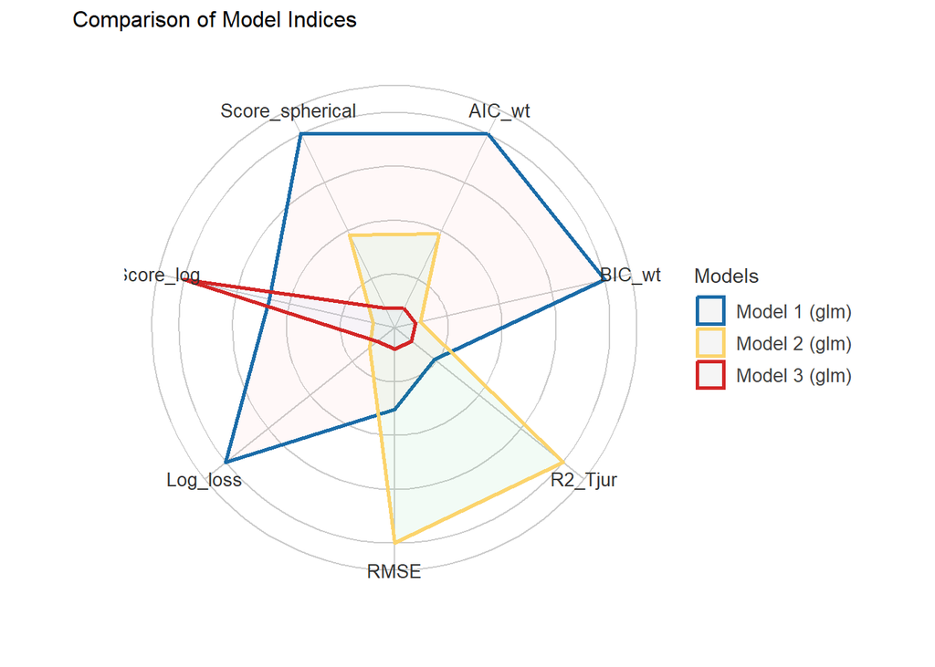

### Estimates

|  | m1 |  |  |  | m2 |  |  |  | m3 |  |  |  |
| --- | --- | --- | --- | --- | --- | --- | --- | --- | --- | --- | --- | --- |
| Predictors | Odds Ratios | std. Error | Statistic | p | Odds Ratios | std. Error | Statistic | p | Odds Ratios | std. Error | Statistic | p |
| (Intercept) | 0.02 (0.02 – 0.03) | 0.00 | -29.82 | **<0.001** | 0.02 (0.02 – 0.03) | 0.00 | -29.72 | **<0.001** | 0.02 (0.02 – 0.03) | 0.00 | -29.66 | **<0.001** |
| depRS b | 1.55 (1.29 – 1.84) | 0.14 | 4.82 | **<0.001** | 1.53 (1.27 – 1.82) | 0.14 | 4.62 | **<0.001** | 1.54 (1.26 – 1.85) | 0.15 | 4.42 | **<0.001** |
| PRS |  |  |  |  | 1.11 (0.88 – 1.41) | 0.14 | 0.88 | 0.378 | 1.12 (0.87 – 1.45) | 0.15 | 0.89 | 0.371 |
| depRS b × PRS |  |  |  |  |  |  |  |  | 0.98 (0.82 – 1.17) | 0.09 | -0.20 | 0.840 |
| Observations | 3145 |  |  |  | 3145 |  |  |  | 3145 |  |  |  |
| R<sup>2</sup> Tjur | 0.011 |  |  |  | 0.011 |  |  |  | 0.011 |  |  |  |

| model | Accuracy | SE | CI | CI_low | CI_high | Method |
| --- | --- | --- | --- | --- | --- | --- |
| 1 | 0.633 | 0.037 | 0.95 | 0.596 | 0.683 | Area under Curve |
| 2 | 0.585 | 0.086 | 0.95 | 0.454 | 0.653 | Area under Curve |
| 3 | 0.613 | 0.069 | 0.95 | 0.530 | 0.699 | Area under Curve |

## intRS + PRS

### Performance metrics

| Name | Model | AIC (weights) | BIC (weights) | Tjur’s R2 | RMSE | Sigma | Log_loss | Score_log | Score_spherical | AICc (weights) | PCP |
| --- | --- | --- | --- | --- | --- | --- | --- | --- | --- | --- | --- |
| Model 1 | glm | 668.1 (0.547) | 680.2 (0.971) | 0.008 | 0.148 | 1.000 | 0.106 | -1.613 | 0.016 | 668.1 (>.999) | 0.956 |
| Model 2 | glm | 669.1 (0.331) | 687.3 (0.029) | 0.009 | 0.148 | 1.000 | 0.105 | -1.614 | 0.016 | (>.999) |  |
| Model 3 | glm | 671.1 (0.122) | 695.3 (<.001) | 0.008 | 0.148 | 1.000 | 0.105 | -1.614 | 0.016 | (>.999) |  |

### Model comparisons

| Name | Model | BF |
| --- | --- | --- |
| Model 1 | glm |  |
| Model 2 | glm | 0.029 |
| Model 3 | glm | 0.018 |

Models were detected as nested (in terms of fixed parameters) and are compared in sequential order.

### Plot

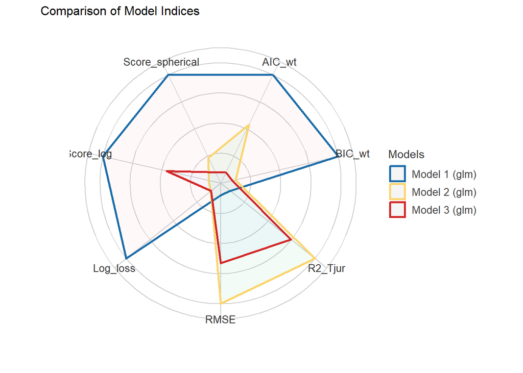

### Estimates

|  | m1 |  |  |  | m2 |  |  |  | m3 |  |  |  |
| --- | --- | --- | --- | --- | --- | --- | --- | --- | --- | --- | --- | --- |
| Predictors | Odds Ratios | std. Error | Statistic | p | Odds Ratios | std. Error | Statistic | p | Odds Ratios | std. Error | Statistic | p |
| (Intercept) | 0.02 (0.02 – 0.03) | 0.00 | -30.12 | **<0.001** | 0.02 (0.02 – 0.03) | 0.00 | -29.99 | **<0.001** | 0.02 (0.02 – 0.03) | 0.00 | -29.97 | **<0.001** |
| intRS b | 1.47 (1.21 – 1.75) | 0.14 | 4.14 | **<0.001** | 1.45 (1.20 – 1.73) | 0.14 | 3.95 | **<0.001** | 1.45 (1.18 – 1.75) | 0.14 | 3.73 | **<0.001** |
| PRS |  |  |  |  | 1.13 (0.89 – 1.43) | 0.14 | 1.00 | 0.318 | 1.13 (0.88 – 1.46) | 0.15 | 0.96 | 0.335 |
| intRS b × PRS |  |  |  |  |  |  |  |  | 0.99 (0.82 – 1.19) | 0.09 | -0.06 | 0.949 |
| Observations | 3145 |  |  |  | 3145 |  |  |  | 3145 |  |  |  |
| R<sup>2</sup> Tjur | 0.008 |  |  |  | 0.009 |  |  |  | 0.008 |  |  |  |

| model | Accuracy | SE | CI | CI_low | CI_high | Method |
| --- | --- | --- | --- | --- | --- | --- |
| 1 | 0.610 | 0.093 | 0.95 | 0.509 | 0.733 | Area under Curve |
| 2 | 0.611 | 0.110 | 0.95 | 0.476 | 0.730 | Area under Curve |
| 3 | 0.602 | 0.041 | 0.95 | 0.550 | 0.643 | Area under Curve |

## envRS combined

### Performance metrics

| Name | Model | AIC (weights) | AICc (weights) | BIC (weights) | Tjur’s R2 | RMSE | Sigma | Log_loss | Score_log | Score_spherical | PCP |
| --- | --- | --- | --- | --- | --- | --- | --- | --- | --- | --- | --- |
| depRS | glm | 1782.0 (0.066) | 1782.0 (0.066) | 1795.8 (0.750) | 0.008 | 0.158 | 1.000 | 0.117 | -5.119 | 0.008 | 0.950 |
| intRS | glm | 1791.9 (<.001) | 1791.9 (<.001) | 1805.8 (0.005) | 0.006 | 0.158 | 1.000 | 0.118 | -5.114 | 0.008 | 0.950 |
| combRS | glm | 1777.3 (0.682) | 1777.3 (0.682) | 1798.1 (0.242) | 0.009 | 0.158 | 1.000 | 0.117 | -5.122 | 0.008 | 0.950 |
| interact | glm | 1779.3 (0.251) | 1779.3 (0.251) | 1807.0 (0.003) | 0.009 | 0.158 | 1.000 | 0.117 | -5.122 | 0.008 | 0.950 |

### Model comparisons

| Name | Model | BF | df | df_diff | Chi2 | p |
| --- | --- | --- | --- | --- | --- | --- |
| depRS | glm |  | 2 |  |  |  |
| combRS | glm | 0.323 | 3 | 1.000 | 6.671 | 0.010 |
| interact | glm | 0.012 | 4 | 1.000 | 0.004 | 0.949 |

Models were detected as nested (in terms of fixed parameters) and are compared in sequential order.

| Name | Model | BF | df | df_diff | Chi2 | p |
| --- | --- | --- | --- | --- | --- | --- |
| intRS | glm |  | 2 |  |  |  |
| combRS | glm | 46.33 | 3 | 1.000 | 16.603 | < .001 |
| interact | glm | 0.012 | 4 | 1.000 | 0.004 | 0.949 |

Models were detected as nested (in terms of fixed parameters) and are compared in sequential order.

### Plot

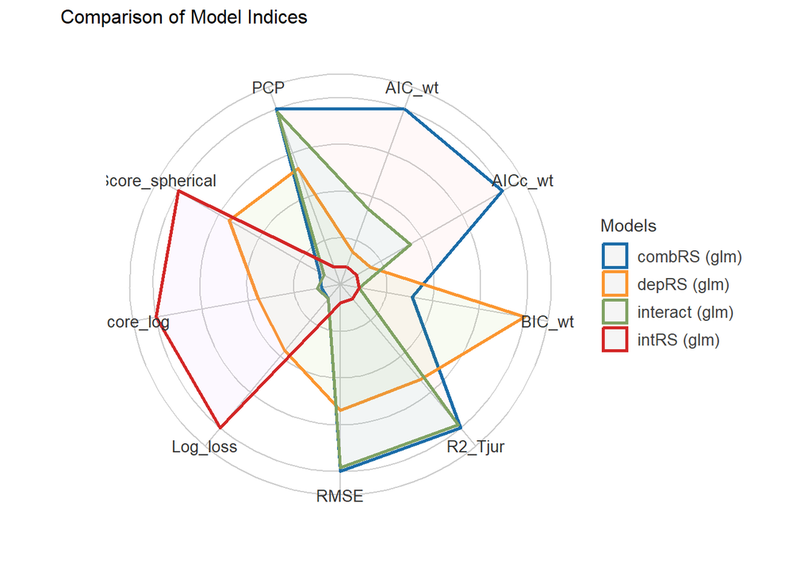

### Estimates

|  | depRS |  |  |  | intRS |  |  |  | depRS+intRS |  |  |  | depRS*intRS |  |  |  |
| --- | --- | --- | --- | --- | --- | --- | --- | --- | --- | --- | --- | --- | --- | --- | --- | --- |
| Predictors | Odds Ratios | std. Error | Statistic | p | Odds Ratios | std. Error | Statistic | p | Odds Ratios | std. Error | Statistic | p | Odds Ratios | std. Error | Statistic | p |
| (Intercept) | 0.02 (0.02 – 0.03) | 0.00 | -48.05 | **<0.001** | 0.02 (0.02 – 0.03) | 0.00 | -48.43 | **<0.001** | 0.02 (0.02 – 0.03) | 0.00 | -47.75 | **<0.001** | 0.02 (0.02 – 0.03) | 0.00 | -45.85 | **<0.001** |
| depRS b | 2.30 (1.80 – 2.90) | 0.28 | 6.89 | **<0.001** |  |  |  |  | 8.56 (3.08 – 23.48) | 4.44 | 4.15 | **<0.001** | 8.60 (3.06 – 23.71) | 4.48 | 4.12 | **<0.001** |
| intRS b |  |  |  |  | 2.01 (1.59 – 2.52) | 0.24 | 5.96 | **<0.001** | 0.27 (0.10 – 0.73) | 0.14 | -2.59 | **0.010** | 0.27 (0.10 – 0.74) | 0.14 | -2.54 | **0.011** |
| depRS b × intRS b |  |  |  |  |  |  |  |  |  |  |  |  | 0.99 (0.75 – 1.27) | 0.13 | -0.06 | 0.950 |
| Observations | 7566 |  |  |  | 7566 |  |  |  | 7566 |  |  |  | 7566 |  |  |  |
| R<sup>2</sup> Tjur | 0.008 |  |  |  | 0.006 |  |  |  | 0.009 |  |  |  | 0.009 |  |  |  |

| model | Accuracy | SE | CI | CI_low | CI_high | Method |
| --- | --- | --- | --- | --- | --- | --- |
| depRS | 0.618 | 0.045 | 0.95 | 0.552 | 0.661 | Area under Curve |
| intRS | 0.602 | 0.046 | 0.95 | 0.570 | 0.672 | Area under Curve |
| combRS | 0.634 | 0.047 | 0.95 | 0.578 | 0.687 | Area under Curve |
| interact | 0.629 | 0.060 | 0.95 | 0.578 | 0.720 | Area under Curve |

# Y2 (longitudinal)

For envRS-only analyses, there are 238 lifetime MDD cases, 33 current MDD cases and 407 cases with lifetime diagnoses of a depressive disorder (Major Depressive Disorder, Persistent Depressive Disorder (dysthymia), Depressive Disorder Unspecified).  
Of those with both envRS and PRS at Y2 (N = 2982), there are 77 lifetime MDD cases, 7 current MDD cases and 150 cases with lifetime diagnoses of a depressive disorder (Major Depressive Disorder, Persistent Depressive Disorder (dysthymia), Depressive Disorder Unspecified).  
*Current analyses use just the lifetime MDD outcome*

## depRS + PRS

### Performance metrics

| Name | Model | AIC (weights) | BIC (weights) | Tjur’s R2 | RMSE | Sigma | Log_loss | Score_log | Score_spherical | AICc (weights) | PCP |
| --- | --- | --- | --- | --- | --- | --- | --- | --- | --- | --- | --- |
| Model 1 | glm | 694.9 (0.111) | 706.9 (0.802) | 0.011 | 0.158 | 1.000 | 0.116 | -2.004 | 0.016 | 694.9 (>.999) | 0.950 |
| Model 2 | glm | 691.8 (0.534) | 709.8 (0.191) | 0.012 | 0.158 | 1.000 | 0.115 | -2.006 | 0.015 | (>.999) |  |
| Model 3 | glm | 692.6 (0.355) | 716.6 (0.006) | 0.013 | 0.158 | 1.000 | 0.115 | -2.005 | 0.015 | (>.999) |  |

### Model comparisons

| Name | Model | BF |
| --- | --- | --- |
| Model 1 | glm |  |
| Model 2 | glm | 0.239 |
| Model 3 | glm | 0.033 |

Models were detected as nested (in terms of fixed parameters) and are compared in sequential order.

### Plot

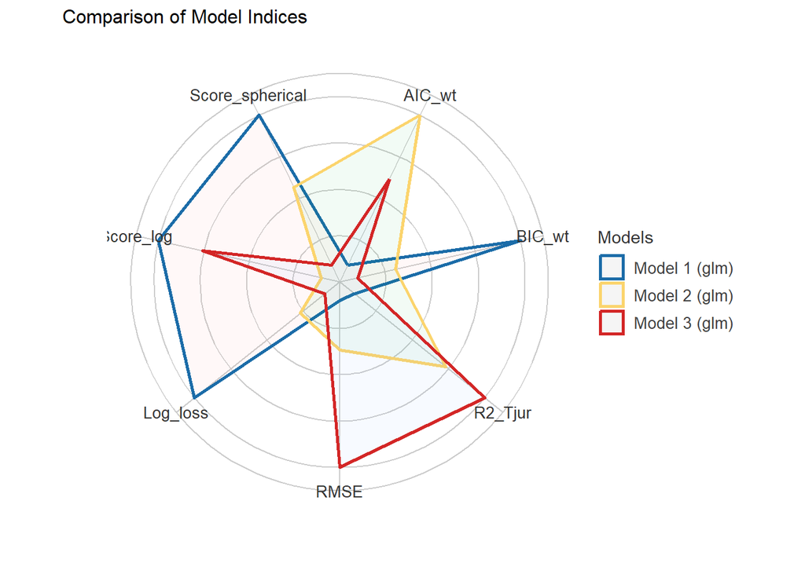

### Estimates

|  | m1 |  |  |  | m2 |  |  |  | m3 |  |  |  |
| --- | --- | --- | --- | --- | --- | --- | --- | --- | --- | --- | --- | --- |
| Predictors | Odds Ratios | std. Error | Statistic | p | Odds Ratios | std. Error | Statistic | p | Odds Ratios | std. Error | Statistic | p |
| (Intercept) | 0.02 (0.02 – 0.03) | 0.00 | -29.67 | **<0.001** | 0.02 (0.02 – 0.03) | 0.00 | -29.08 | **<0.001** | 0.02 (0.02 – 0.03) | 0.00 | -28.62 | **<0.001** |
| depRS b | 1.62 (1.35 – 1.93) | 0.15 | 5.30 | **<0.001** | 1.58 (1.31 – 1.89) | 0.15 | 4.97 | **<0.001** | 1.64 (1.35 – 1.97) | 0.16 | 5.11 | **<0.001** |
| PRS |  |  |  |  | 1.30 (1.04 – 1.65) | 0.15 | 2.26 | **0.024** | 1.38 (1.07 – 1.77) | 0.18 | 2.50 | **0.012** |
| depRS b × PRS |  |  |  |  |  |  |  |  | 0.90 (0.74 – 1.09) | 0.09 | -1.09 | 0.278 |
| Observations | 2982 |  |  |  | 2982 |  |  |  | 2982 |  |  |  |
| R<sup>2</sup> Tjur | 0.011 |  |  |  | 0.012 |  |  |  | 0.013 |  |  |  |

| model | Accuracy | SE | CI | CI_low | CI_high | Method |
| --- | --- | --- | --- | --- | --- | --- |
| 1 | 0.639 | 0.121 | 0.95 | 0.501 | 0.736 | Area under Curve |
| 2 | 0.665 | 0.041 | 0.95 | 0.617 | 0.716 | Area under Curve |
| 3 | 0.656 | 0.041 | 0.95 | 0.595 | 0.693 | Area under Curve |

## intRS + PRS

### Performance metrics

| Name | Model | AIC (weights) | BIC (weights) | Tjur’s R2 | RMSE | Sigma | Log_loss | Score_log | Score_spherical | AICc (weights) | PCP |
| --- | --- | --- | --- | --- | --- | --- | --- | --- | --- | --- | --- |
| Model 1 | glm | 694.0 (0.124) | 706.0 (0.798) | 0.010 | 0.158 | 1.000 | 0.116 | -2.005 | 0.016 | 694.0 (>.999) | 0.950 |
| Model 2 | glm | 690.8 (0.617) | 708.8 (0.198) | 0.012 | 0.158 | 1.000 | 0.115 | -2.006 | 0.015 | (>.999) |  |
| Model 3 | glm | 692.5 (0.259) | 716.5 (0.004) | 0.012 | 0.158 | 1.000 | 0.115 | -2.005 | 0.015 | (>.999) |  |

### Model comparisons

| Name | Model | BF |
| --- | --- | --- |
| Model 1 | glm |  |
| Model 2 | glm | 0.248 |
| Model 3 | glm | 0.021 |

Models were detected as nested (in terms of fixed parameters) and are compared in sequential order.

### Plot

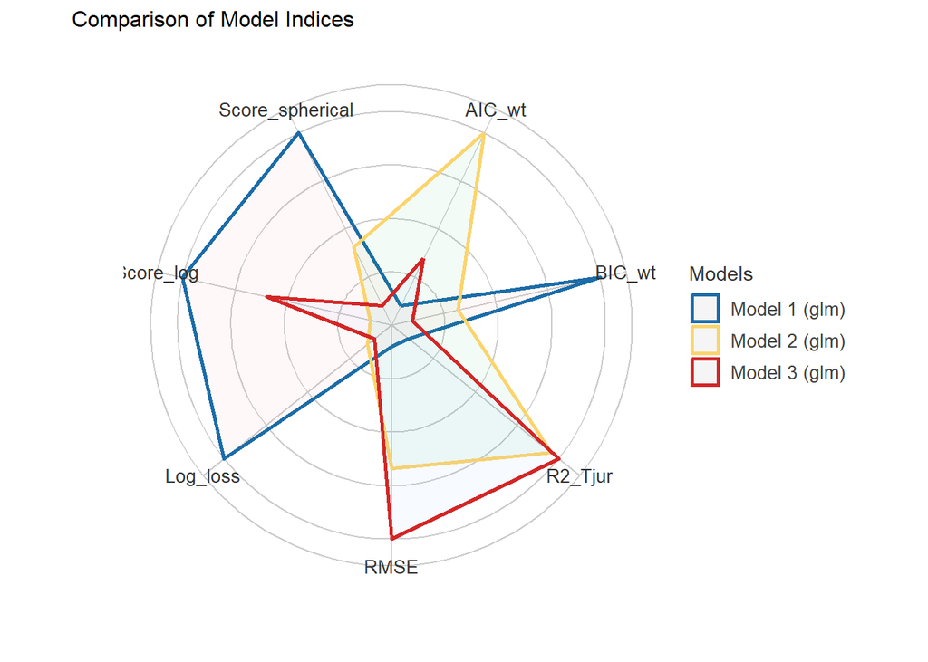

### Estimates

|  | m1 |  |  |  | m2 |  |  |  | m3 |  |  |  |
| --- | --- | --- | --- | --- | --- | --- | --- | --- | --- | --- | --- | --- |
| Predictors | Odds Ratios | std. Error | Statistic | p | Odds Ratios | std. Error | Statistic | p | Odds Ratios | std. Error | Statistic | p |
| (Intercept) | 0.02 (0.02 – 0.03) | 0.00 | -29.64 | **<0.001** | 0.02 (0.02 – 0.03) | 0.00 | -29.06 | **<0.001** | 0.02 (0.02 – 0.03) | 0.00 | -28.82 | **<0.001** |
| intRS b | 1.63 (1.36 – 1.94) | 0.15 | 5.41 | **<0.001** | 1.59 (1.32 – 1.89) | 0.14 | 5.09 | **<0.001** | 1.62 (1.33 – 1.95) | 0.16 | 4.97 | **<0.001** |
| PRS |  |  |  |  | 1.31 (1.04 – 1.65) | 0.15 | 2.28 | **0.023** | 1.34 (1.04 – 1.73) | 0.17 | 2.29 | **0.022** |
| intRS b × PRS |  |  |  |  |  |  |  |  | 0.95 (0.79 – 1.15) | 0.09 | -0.52 | 0.605 |
| Observations | 2982 |  |  |  | 2982 |  |  |  | 2982 |  |  |  |
| R<sup>2</sup> Tjur | 0.010 |  |  |  | 0.012 |  |  |  | 0.012 |  |  |  |

| model | Accuracy | SE | CI | CI_low | CI_high | Method |
| --- | --- | --- | --- | --- | --- | --- |
| 1 | 0.662 | 0.052 | 0.95 | 0.611 | 0.737 | Area under Curve |
| 2 | 0.654 | 0.094 | 0.95 | 0.562 | 0.772 | Area under Curve |
| 3 | 0.664 | 0.038 | 0.95 | 0.614 | 0.710 | Area under Curve |

## envRS combined

### Performance metrics

| Name | Model | AIC (weights) | AICc (weights) | BIC (weights) | Tjur’s R2 | RMSE | Sigma | Log_loss | Score_log | Score_spherical | PCP |
| --- | --- | --- | --- | --- | --- | --- | --- | --- | --- | --- | --- |
| depRS | glm | 2034.2 (0.376) | 2034.2 (0.376) | 2047.9 (0.641) | 0.008 | 0.180 | 1.000 | 0.144 | -8.158 | 0.006 | 0.935 |
| intRS | glm | 2035.4 (0.205) | 2035.4 (0.205) | 2049.1 (0.350) | 0.008 | 0.180 | 1.000 | 0.144 | -8.157 | 0.007 | 0.935 |
| combRS | glm | 2035.9 (0.158) | 2035.9 (0.158) | 2056.5 (0.009) | 0.008 | 0.180 | 1.000 | 0.144 | -8.158 | 0.006 | 0.935 |
| interact | glm | 2034.9 (0.260) | 2034.9 (0.260) | 2062.3 (<.001) | 0.008 | 0.180 | 1.000 | 0.144 | -8.154 | 0.006 | 0.935 |

### Model comparisons

| Name | Model | BF | df | df_diff | Chi2 | p |
| --- | --- | --- | --- | --- | --- | --- |
| depRS | glm |  | 2 |  |  |  |
| combRS | glm | 0.014 | 3 | 1.000 | 0.267 | 0.605 |
| interact | glm | 0.053 | 4 | 1.000 | 2.998 | 0.083 |

Models were detected as nested (in terms of fixed parameters) and are compared in sequential order.

| Name | Model | BF | df | df_diff | Chi2 | p |
| --- | --- | --- | --- | --- | --- | --- |
| intRS | glm |  | 2 |  |  |  |
| combRS | glm | 0.025 | 3 | 1.000 | 1.479 | 0.224 |
| interact | glm | 0.053 | 4 | 1.000 | 2.998 | 0.083 |

Models were detected as nested (in terms of fixed parameters) and are compared in sequential order.

### Plot

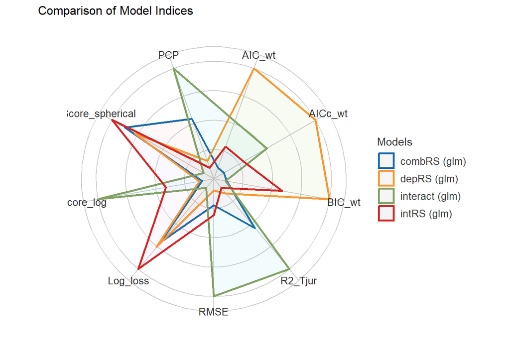

### Estimates

|  | depRS |  |  |  | intRS |  |  |  | depRS+intRS |  |  |  | depRS*intRS |  |  |  |
| --- | --- | --- | --- | --- | --- | --- | --- | --- | --- | --- | --- | --- | --- | --- | --- | --- |
| Predictors | Odds Ratios | std. Error | Statistic | p | Odds Ratios | std. Error | Statistic | p | Odds Ratios | std. Error | Statistic | p | Odds Ratios | std. Error | Statistic | p |
| (Intercept) | 0.03 (0.03 – 0.04) | 0.00 | -48.89 | **<0.001** | 0.03 (0.03 – 0.04) | 0.00 | -48.89 | **<0.001** | 0.03 (0.03 – 0.04) | 0.00 | -48.87 | **<0.001** | 0.03 (0.03 – 0.04) | 0.00 | -45.51 | **<0.001** |
| depRS b | 2.34 (1.87 – 2.91) | 0.26 | 7.52 | **<0.001** |  |  |  |  | 1.83 (0.69 – 4.75) | 0.90 | 1.22 | 0.221 | 2.09 (0.78 – 5.49) | 1.04 | 1.49 | 0.137 |
| intRS b |  |  |  |  | 2.22 (1.79 – 2.72) | 0.24 | 7.42 | **<0.001** | 1.27 (0.51 – 3.19) | 0.59 | 0.52 | 0.605 | 1.44 (0.57 – 3.62) | 0.67 | 0.77 | 0.441 |
| depRS b × intRS b |  |  |  |  |  |  |  |  |  |  |  |  | 0.78 (0.57 – 1.03) | 0.12 | -1.66 | 0.096 |
| Observations | 7033 |  |  |  | 7033 |  |  |  | 7033 |  |  |  | 7033 |  |  |  |
| R<sup>2</sup> Tjur | 0.008 |  |  |  | 0.008 |  |  |  | 0.008 |  |  |  | 0.008 |  |  |  |

| model | Accuracy | SE | CI | CI_low | CI_high | Method |
| --- | --- | --- | --- | --- | --- | --- |
| depRS | 0.635 | 0.054 | 0.95 | 0.592 | 0.718 | Area under Curve |
| intRS | 0.626 | 0.048 | 0.95 | 0.563 | 0.685 | Area under Curve |
| combRS | 0.629 | 0.013 | 0.95 | 0.613 | 0.643 | Area under Curve |
| interact | 0.632 | 0.036 | 0.95 | 0.592 | 0.679 | Area under Curve |

# Lifetime MDD diagnosis (parent)

Depression diagnoses (lifetime and current) from *parent-reported* KSADS are available at baseline (N=7582) and year 2 (N=6953).

# Baseline (cross-sectional)

## depRS + PRS

### Performance metrics

| Name | Model | AIC (weights) | BIC (weights) | Tjur’s R2 | RMSE | Sigma | Log_loss | Score_log | Score_spherical | AICc (weights) | PCP |
| --- | --- | --- | --- | --- | --- | --- | --- | --- | --- | --- | --- |
| Model 1 | glm | 663.1 (0.573) | 675.2 (0.974) | 0.011 | 0.148 | 1.000 | 0.105 | -1.615 | 0.016 | 663.1 (>.999) | 0.956 |
| Model 2 | glm | 664.3 (0.311) | 682.5 (0.026) | 0.011 | 0.148 | 1.000 | 0.105 | -1.616 | 0.016 | (>.999) |  |
| Model 3 | glm | 666.3 (0.117) | 690.5 (<.001) | 0.011 | 0.148 | 1.000 | 0.105 | -1.615 | 0.016 | (>.999) |  |

### Model comparisons

| Name | Model | BF |
| --- | --- | --- |
| Model 1 | glm |  |
| Model 2 | glm | 0.026 |
| Model 3 | glm | 0.018 |

Models were detected as nested (in terms of fixed parameters) and are compared in sequential order.

### Plot

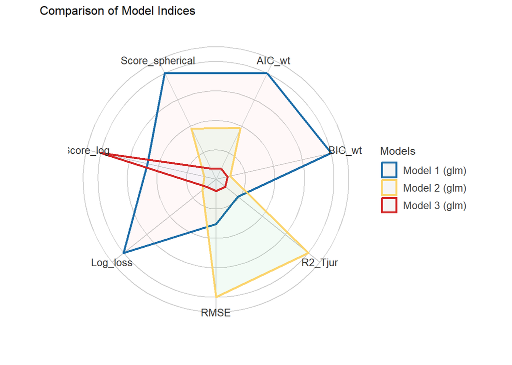

### Estimates

|  | m1 |  |  |  | m2 |  |  |  | m3 |  |  |  |
| --- | --- | --- | --- | --- | --- | --- | --- | --- | --- | --- | --- | --- |
| Predictors | Odds Ratios | std. Error | Statistic | p | Odds Ratios | std. Error | Statistic | p | Odds Ratios | std. Error | Statistic | p |
| (Intercept) | 0.02 (0.02 – 0.03) | 0.00 | -29.82 | **<0.001** | 0.02 (0.02 – 0.03) | 0.00 | -29.72 | **<0.001** | 0.02 (0.02 – 0.03) | 0.00 | -29.66 | **<0.001** |
| depRS b | 1.55 (1.29 – 1.84) | 0.14 | 4.82 | **<0.001** | 1.53 (1.27 – 1.82) | 0.14 | 4.62 | **<0.001** | 1.54 (1.26 – 1.85) | 0.15 | 4.42 | **<0.001** |
| PRS |  |  |  |  | 1.11 (0.88 – 1.41) | 0.14 | 0.88 | 0.378 | 1.12 (0.87 – 1.45) | 0.15 | 0.89 | 0.371 |
| depRS b × PRS |  |  |  |  |  |  |  |  | 0.98 (0.82 – 1.17) | 0.09 | -0.20 | 0.840 |
| Observations | 3145 |  |  |  | 3145 |  |  |  | 3145 |  |  |  |
| R<sup>2</sup> Tjur | 0.011 |  |  |  | 0.011 |  |  |  | 0.011 |  |  |  |

| model | Accuracy | SE | CI | CI_low | CI_high | Method |
| --- | --- | --- | --- | --- | --- | --- |
| 1 | 0.629 | 0.053 | 0.95 | 0.574 | 0.689 | Area under Curve |
| 2 | 0.630 | 0.034 | 0.95 | 0.588 | 0.675 | Area under Curve |
| 3 | 0.635 | 0.051 | 0.95 | 0.577 | 0.706 | Area under Curve |

## intRS + PRS

### Performance metrics

| Name | Model | AIC (weights) | BIC (weights) | Tjur’s R2 | RMSE | Sigma | Log_loss | Score_log | Score_spherical | AICc (weights) | PCP |
| --- | --- | --- | --- | --- | --- | --- | --- | --- | --- | --- | --- |
| Model 1 | glm | 668.1 (0.547) | 680.2 (0.971) | 0.008 | 0.148 | 1.000 | 0.106 | -1.613 | 0.016 | 668.1 (>.999) | 0.956 |
| Model 2 | glm | 669.1 (0.331) | 687.3 (0.029) | 0.009 | 0.148 | 1.000 | 0.105 | -1.614 | 0.016 | (>.999) |  |
| Model 3 | glm | 671.1 (0.122) | 695.3 (<.001) | 0.008 | 0.148 | 1.000 | 0.105 | -1.614 | 0.016 | (>.999) |  |

### Model comparisons

| Name | Model | BF |
| --- | --- | --- |
| Model 1 | glm |  |
| Model 2 | glm | 0.029 |
| Model 3 | glm | 0.018 |

Models were detected as nested (in terms of fixed parameters) and are compared in sequential order.

### Plot

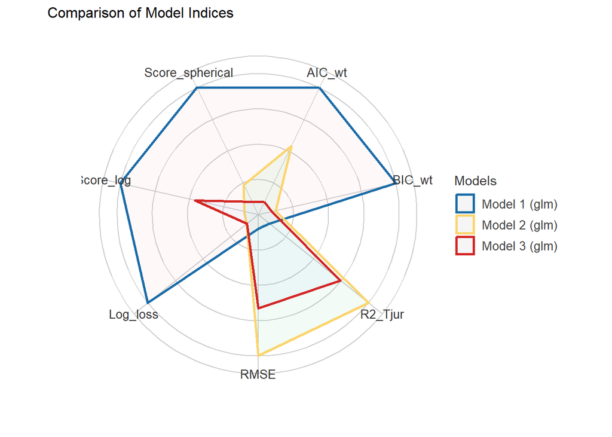

### Estimates

|  | m1 |  |  |  | m2 |  |  |  | m3 |  |  |  |
| --- | --- | --- | --- | --- | --- | --- | --- | --- | --- | --- | --- | --- |
| Predictors | Odds Ratios | std. Error | Statistic | p | Odds Ratios | std. Error | Statistic | p | Odds Ratios | std. Error | Statistic | p |
| (Intercept) | 0.02 (0.02 – 0.03) | 0.00 | -30.12 | **<0.001** | 0.02 (0.02 – 0.03) | 0.00 | -29.99 | **<0.001** | 0.02 (0.02 – 0.03) | 0.00 | -29.97 | **<0.001** |
| intRS b | 1.47 (1.21 – 1.75) | 0.14 | 4.14 | **<0.001** | 1.45 (1.20 – 1.73) | 0.14 | 3.95 | **<0.001** | 1.45 (1.18 – 1.75) | 0.14 | 3.73 | **<0.001** |
| PRS |  |  |  |  | 1.13 (0.89 – 1.43) | 0.14 | 1.00 | 0.318 | 1.13 (0.88 – 1.46) | 0.15 | 0.96 | 0.335 |
| intRS b × PRS |  |  |  |  |  |  |  |  | 0.99 (0.82 – 1.19) | 0.09 | -0.06 | 0.949 |
| Observations | 3145 |  |  |  | 3145 |  |  |  | 3145 |  |  |  |
| R<sup>2</sup> Tjur | 0.008 |  |  |  | 0.009 |  |  |  | 0.008 |  |  |  |

| model | Accuracy | SE | CI | CI_low | CI_high | Method |
| --- | --- | --- | --- | --- | --- | --- |
| 1 | 0.617 | 0.046 | 0.95 | 0.574 | 0.671 | Area under Curve |
| 2 | 0.613 | 0.060 | 0.95 | 0.549 | 0.696 | Area under Curve |
| 3 | 0.608 | 0.109 | 0.95 | 0.530 | 0.777 | Area under Curve |

## envRS combined

### Performance metrics

| Name | Model | AIC (weights) | AICc (weights) | BIC (weights) | Tjur’s R2 | RMSE | Sigma | Log_loss | Score_log | Score_spherical | PCP |
| --- | --- | --- | --- | --- | --- | --- | --- | --- | --- | --- | --- |
| depRS | glm | 1629.1 (0.019) | 1629.1 (0.019) | 1643.0 (0.879) | 0.032 | 0.155 | 1.000 | 0.107 | -4.946 | 0.008 | 0.952 |
| intRS | glm | 1634.3 (0.001) | 1634.3 (0.001) | 1648.2 (0.065) | 0.032 | 0.155 | 1.000 | 0.108 | -4.936 | 0.008 | 0.952 |
| combRS | glm | 1630.8 (0.008) | 1630.8 (0.008) | 1651.6 (0.012) | 0.032 | 0.155 | 1.000 | 0.107 | -4.946 | 0.008 | 0.952 |
| interact | glm | 1621.3 (0.971) | 1621.3 (0.971) | 1649.0 (0.044) | 0.032 | 0.154 | 1.000 | 0.106 | -4.904 | 0.008 | 0.952 |

### Model comparisons

| Name | Model | BF | df | df_diff | Chi2 | p |
| --- | --- | --- | --- | --- | --- | --- |
| depRS | glm |  | 2 |  |  |  |
| combRS | glm | 0.014 | 3 | 1.000 | 0.342 | 0.559 |
| interact | glm | 3.67 | 4 | 1.000 | 11.534 | < .001 |

Models were detected as nested (in terms of fixed parameters) and are compared in sequential order.

| Name | Model | BF | df | df_diff | Chi2 | p |
| --- | --- | --- | --- | --- | --- | --- |
| intRS | glm |  | 2 |  |  |  |
| combRS | glm | 0.184 | 3 | 1.000 | 5.548 | 0.018 |
| interact | glm | 3.67 | 4 | 1.000 | 11.534 | < .001 |

Models were detected as nested (in terms of fixed parameters) and are compared in sequential order.

### Plot

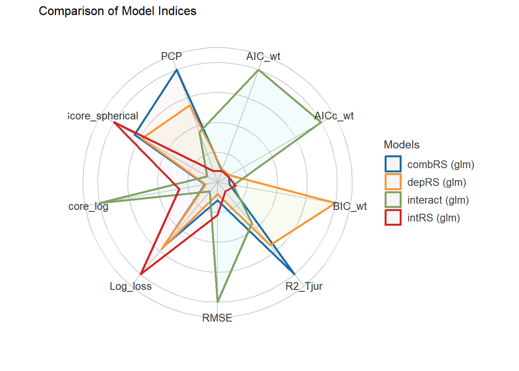

### Estimates

|  | depRS |  |  |  | intRS |  |  |  | depRS+intRS |  |  |  | depRS*intRS |  |  |  |
| --- | --- | --- | --- | --- | --- | --- | --- | --- | --- | --- | --- | --- | --- | --- | --- | --- |
| Predictors | Odds Ratios | std. Error | Statistic | p | Odds Ratios | std. Error | Statistic | p | Odds Ratios | std. Error | Statistic | p | Odds Ratios | std. Error | Statistic | p |
| (Intercept) | 0.02 (0.02 – 0.02) | 0.00 | -44.40 | **<0.001** | 0.02 (0.02 – 0.02) | 0.00 | -44.46 | **<0.001** | 0.02 (0.02 – 0.02) | 0.00 | -44.39 | **<0.001** | 0.02 (0.02 – 0.02) | 0.00 | -42.23 | **<0.001** |
| depRS b | 4.48 (3.60 – 5.57) | 0.50 | 13.44 | **<0.001** |  |  |  |  | 3.35 (1.23 – 9.03) | 1.71 | 2.38 | **0.017** | 4.85 (1.77 – 13.11) | 2.48 | 3.09 | **0.002** |
| intRS b |  |  |  |  | 4.06 (3.30 – 4.99) | 0.43 | 13.25 | **<0.001** | 1.33 (0.52 – 3.44) | 0.64 | 0.58 | 0.559 | 1.73 (0.67 – 4.44) | 0.83 | 1.14 | 0.255 |
| depRS b × intRS b |  |  |  |  |  |  |  |  |  |  |  |  | 0.64 (0.47 – 0.83) | 0.09 | -3.12 | **0.002** |
| Observations | 7582 |  |  |  | 7582 |  |  |  | 7582 |  |  |  | 7582 |  |  |  |
| R<sup>2</sup> Tjur | 0.032 |  |  |  | 0.032 |  |  |  | 0.032 |  |  |  | 0.032 |  |  |  |

| model | Accuracy | SE | CI | CI_low | CI_high | Method |
| --- | --- | --- | --- | --- | --- | --- |
| depRS | 0.754 | 0.016 | 0.95 | 0.731 | 0.771 | Area under Curve |
| intRS | 0.748 | 0.029 | 0.95 | 0.714 | 0.784 | Area under Curve |
| combRS | 0.753 | 0.028 | 0.95 | 0.716 | 0.775 | Area under Curve |
| interact | 0.747 | 0.064 | 0.95 | 0.665 | 0.826 | Area under Curve |

# Y2 (longitudinal)

For envRS-only analyses, there are 276 lifetime MDD cases, 32 current MDD cases and 555 cases with lifetime diagnoses of a depressive disorder (Major Depressive Disorder, Persistent Depressive Disorder (dysthymia), Depressive Disorder Unspecified).  
Of those with both envRS and PRS at Y2 (N = 2957), there are 118 lifetime MDD cases, 19 current MDD cases and 252 cases with lifetime diagnoses of a depressive disorder (Major Depressive Disorder, Persistent Depressive Disorder (dysthymia), Depressive Disorder Unspecified).  
Current analyses use *just* the lifetime MDD outcome.

## depRS + PRS

### Performance metrics

| Name | Model | AIC (weights) | BIC (weights) | Tjur’s R2 | RMSE | Sigma | Log_loss | Score_log | Score_spherical | AICc (weights) | PCP |
| --- | --- | --- | --- | --- | --- | --- | --- | --- | --- | --- | --- |
| Model 1 | glm | 933.2 (0.254) | 945.2 (0.904) | 0.031 | 0.193 | 1.000 | 0.157 | -4.822 | 0.013 | 933.2 (>.999) | 0.926 |
| Model 2 | glm | 931.8 (0.526) | 949.7 (0.094) | 0.032 | 0.193 | 1.000 | 0.157 | -4.826 | 0.012 | (>.999) |  |
| Model 3 | glm | 933.5 (0.220) | 957.5 (0.002) | 0.032 | 0.193 | 1.000 | 0.156 | -4.823 | 0.012 | (>.999) |  |

### Model comparisons

| Name | Model | BF |
| --- | --- | --- |
| Model 1 | glm |  |
| Model 2 | glm | 0.104 |
| Model 3 | glm | 0.021 |

Models were detected as nested (in terms of fixed parameters) and are compared in sequential order.

### Plot

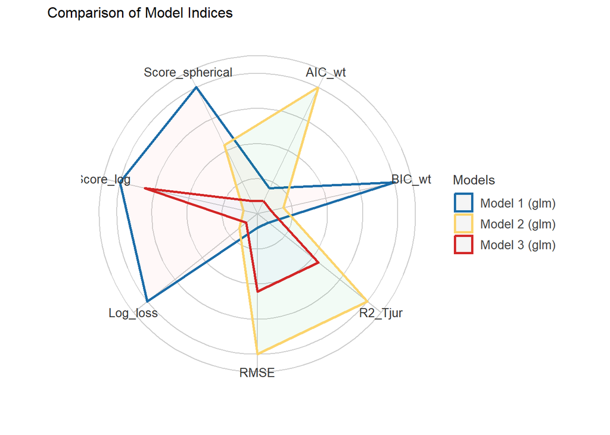

### Estimates

|  | m1 |  |  |  | m2 |  |  |  | m3 |  |  |  |
| --- | --- | --- | --- | --- | --- | --- | --- | --- | --- | --- | --- | --- |
| Predictors | Odds Ratios | std. Error | Statistic | p | Odds Ratios | std. Error | Statistic | p | Odds Ratios | std. Error | Statistic | p |
| (Intercept) | 0.03 (0.03 – 0.04) | 0.00 | -31.35 | **<0.001** | 0.03 (0.03 – 0.04) | 0.00 | -31.10 | **<0.001** | 0.03 (0.03 – 0.04) | 0.00 | -30.94 | **<0.001** |
| depRS b | 1.86 (1.60 – 2.14) | 0.14 | 8.37 | **<0.001** | 1.82 (1.57 – 2.11) | 0.14 | 8.05 | **<0.001** | 1.84 (1.58 – 2.15) | 0.14 | 7.88 | **<0.001** |
| PRS |  |  |  |  | 1.20 (0.99 – 1.45) | 0.12 | 1.86 | 0.063 | 1.23 (0.99 – 1.52) | 0.13 | 1.88 | 0.060 |
| depRS b × PRS |  |  |  |  |  |  |  |  | 0.96 (0.83 – 1.12) | 0.07 | -0.50 | 0.615 |
| Observations | 2957 |  |  |  | 2957 |  |  |  | 2957 |  |  |  |
| R<sup>2</sup> Tjur | 0.031 |  |  |  | 0.032 |  |  |  | 0.032 |  |  |  |

| model | Accuracy | SE | CI | CI_low | CI_high | Method |
| --- | --- | --- | --- | --- | --- | --- |
| 1 | 0.683 | 0.108 | 0.95 | 0.581 | 0.820 | Area under Curve |
| 2 | 0.702 | 0.036 | 0.95 | 0.656 | 0.744 | Area under Curve |
| 3 | 0.696 | 0.045 | 0.95 | 0.646 | 0.731 | Area under Curve |

## intRS + PRS

### Performance metrics

| Name | Model | AIC (weights) | BIC (weights) | Tjur’s R2 | RMSE | Sigma | Log_loss | Score_log | Score_spherical | AICc (weights) | PCP |
| --- | --- | --- | --- | --- | --- | --- | --- | --- | --- | --- | --- |
| Model 1 | glm | 936.0 (0.226) | 948.0 (0.893) | 0.029 | 0.193 | 1.000 | 0.158 | -4.817 | 0.013 | 936.0 (>.999) | 0.926 |
| Model 2 | glm | 934.3 (0.533) | 952.3 (0.105) | 0.031 | 0.193 | 1.000 | 0.157 | -4.822 | 0.012 | (>.999) |  |
| Model 3 | glm | 935.9 (0.241) | 959.8 (0.002) | 0.030 | 0.193 | 1.000 | 0.157 | -4.818 | 0.012 | (>.999) |  |

### Model comparisons

| Name | Model | BF |
| --- | --- | --- |
| Model 1 | glm |  |
| Model 2 | glm | 0.118 |
| Model 3 | glm | 0.023 |

Models were detected as nested (in terms of fixed parameters) and are compared in sequential order.

### Plot

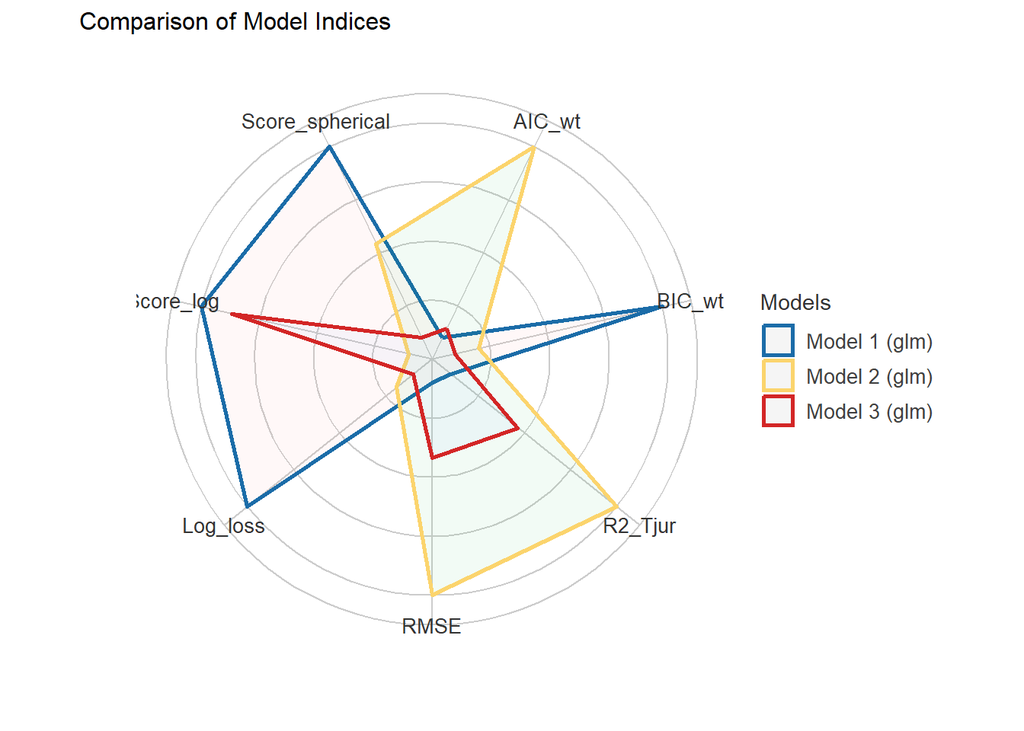

### Estimates

|  | m1 |  |  |  | m2 |  |  |  | m3 |  |  |  |
| --- | --- | --- | --- | --- | --- | --- | --- | --- | --- | --- | --- | --- |
| Predictors | Odds Ratios | std. Error | Statistic | p | Odds Ratios | std. Error | Statistic | p | Odds Ratios | std. Error | Statistic | p |
| (Intercept) | 0.03 (0.03 – 0.04) | 0.00 | -31.44 | **<0.001** | 0.03 (0.03 – 0.04) | 0.00 | -31.19 | **<0.001** | 0.03 (0.03 – 0.04) | 0.00 | -30.97 | **<0.001** |
| intRS b | 1.83 (1.58 – 2.11) | 0.13 | 8.20 | **<0.001** | 1.79 (1.55 – 2.07) | 0.13 | 7.89 | **<0.001** | 1.82 (1.56 – 2.12) | 0.14 | 7.74 | **<0.001** |
| PRS |  |  |  |  | 1.20 (1.00 – 1.45) | 0.12 | 1.92 | 0.054 | 1.24 (1.01 – 1.54) | 0.13 | 2.00 | **0.045** |
| intRS b × PRS |  |  |  |  |  |  |  |  | 0.95 (0.82 – 1.11) | 0.07 | -0.64 | 0.521 |
| Observations | 2957 |  |  |  | 2957 |  |  |  | 2957 |  |  |  |
| R<sup>2</sup> Tjur | 0.029 |  |  |  | 0.031 |  |  |  | 0.030 |  |  |  |

| model | Accuracy | SE | CI | CI_low | CI_high | Method |
| --- | --- | --- | --- | --- | --- | --- |
| 1 | 0.693 | 0.044 | 0.95 | 0.662 | 0.761 | Area under Curve |
| 2 | 0.705 | 0.050 | 0.95 | 0.634 | 0.759 | Area under Curve |
| 3 | 0.698 | 0.050 | 0.95 | 0.630 | 0.757 | Area under Curve |

## envRS combined

### Performance metrics

| Name | Model | AIC (weights) | AICc (weights) | BIC (weights) | Tjur’s R2 | RMSE | Sigma | Log_loss | Score_log | Score_spherical | PCP |
| --- | --- | --- | --- | --- | --- | --- | --- | --- | --- | --- | --- |
| depRS | glm | 2204.0 (0.090) | 2204.0 (0.090) | 2217.7 (0.188) | 0.024 | 0.193 | 1.000 | 0.158 | -11.243 | 0.005 | 0.926 |
| intRS | glm | 2201.1 (0.384) | 2201.1 (0.384) | 2214.8 (0.798) | 0.025 | 0.193 | 1.000 | 0.158 | -11.244 | 0.006 | 0.926 |
| combRS | glm | 2202.4 (0.198) | 2202.4 (0.198) | 2223.0 (0.013) | 0.025 | 0.193 | 1.000 | 0.158 | -11.246 | 0.006 | 0.926 |
| interact | glm | 2201.4 (0.328) | 2201.4 (0.328) | 2228.8 (<.001) | 0.024 | 0.193 | 1.000 | 0.158 | -11.219 | 0.005 | 0.926 |

### Model comparisons

| Name | Model | BF | df | df_diff | Chi2 | p |
| --- | --- | --- | --- | --- | --- | --- |
| depRS | glm |  | 2 |  |  |  |
| combRS | glm | 0.071 | 3 | 1.000 | 3.569 | 0.059 |
| interact | glm | 0.054 | 4 | 1.000 | 3.015 | 0.082 |

Models were detected as nested (in terms of fixed parameters) and are compared in sequential order.

| Name | Model | BF | df | df_diff | Chi2 | p |
| --- | --- | --- | --- | --- | --- | --- |
| intRS | glm |  | 2 |  |  |  |
| combRS | glm | 0.017 | 3 | 1.000 | 0.672 | 0.412 |
| interact | glm | 0.054 | 4 | 1.000 | 3.015 | 0.082 |

Models were detected as nested (in terms of fixed parameters) and are compared in sequential order.

### Plot

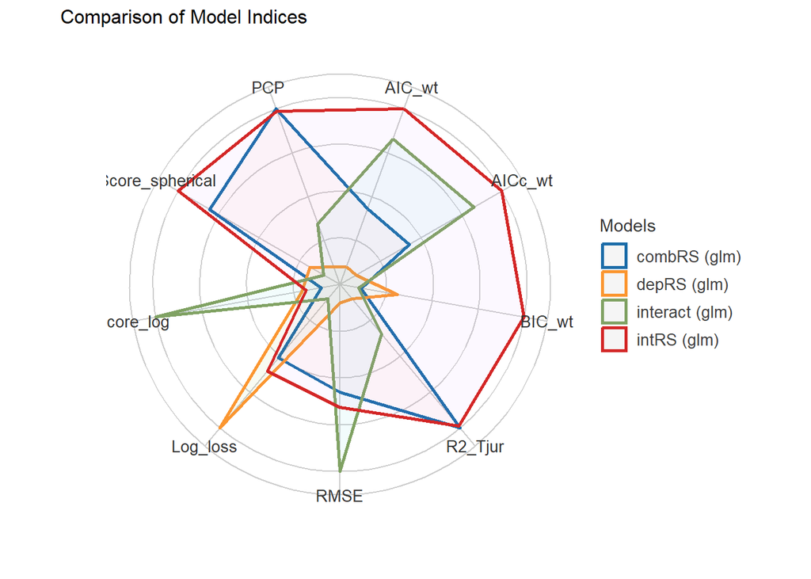

### Estimates

|  | depRS |  |  |  | intRS |  |  |  | depRS+intRS |  |  |  | depRS*intRS |  |  |  |
| --- | --- | --- | --- | --- | --- | --- | --- | --- | --- | --- | --- | --- | --- | --- | --- | --- |
| Predictors | Odds Ratios | std. Error | Statistic | p | Odds Ratios | std. Error | Statistic | p | Odds Ratios | std. Error | Statistic | p | Odds Ratios | std. Error | Statistic | p |
| (Intercept) | 0.04 (0.03 – 0.04) | 0.00 | -48.56 | **<0.001** | 0.04 (0.03 – 0.04) | 0.00 | -48.45 | **<0.001** | 0.04 (0.03 – 0.04) | 0.00 | -48.45 | **<0.001** | 0.04 (0.03 – 0.04) | 0.00 | -46.58 | **<0.001** |
| depRS b | 3.29 (2.70 – 4.01) | 0.33 | 11.79 | **<0.001** |  |  |  |  | 1.45 (0.60 – 3.47) | 0.65 | 0.82 | 0.411 | 1.69 (0.69 – 4.11) | 0.77 | 1.16 | 0.247 |
| intRS b |  |  |  |  | 3.13 (2.59 – 3.77) | 0.30 | 11.94 | **<0.001** | 2.23 (0.97 – 5.14) | 0.95 | 1.88 | 0.060 | 2.46 (1.07 – 5.67) | 1.04 | 2.11 | **0.035** |
| depRS b × intRS b |  |  |  |  |  |  |  |  |  |  |  |  | 0.80 (0.62 – 1.03) | 0.10 | -1.70 | 0.089 |
| Observations | 6953 |  |  |  | 6953 |  |  |  | 6953 |  |  |  | 6953 |  |  |  |
| R<sup>2</sup> Tjur | 0.024 |  |  |  | 0.025 |  |  |  | 0.025 |  |  |  | 0.024 |  |  |  |

| model | Accuracy | SE | CI | CI_low | CI_high | Method |
| --- | --- | --- | --- | --- | --- | --- |
| depRS | 0.681 | 0.034 | 0.95 | 0.639 | 0.724 | Area under Curve |
| intRS | 0.687 | 0.064 | 0.95 | 0.594 | 0.739 | Area under Curve |
| combRS | 0.683 | 0.053 | 0.95 | 0.624 | 0.752 | Area under Curve |
| interact | 0.680 | 0.057 | 0.95 | 0.597 | 0.734 | Area under Curve |